# p8105_hw3_ys3298

Yimeng SHANG

10/3/2019

```r
library(p8105.datasets)
library(tidyverse)
library(patchwork)
data("instacart")
data("brfss_smart2010")
accel = read_csv("./accel_data.csv")
```

# Problem1

## Short description

**The size and structure of the data:** There are 1384617 observations and 15 variables in the data. It’s a (1384617, 15) dataframe. Most of the variable types are integers and some are characters.

**Some key variables:** Product name; aisle; department; order number and so on.

**illstrative examples of observations:** For the 1st order, there’re 8 different kind of products. Eval set is train. In details, the first product is Bulgarian Yogurt, aisle id is 120, department id is 16, aisle is yogurt, department is dairy eggs. For the second observations, aisle id is 108, department id is 16, aisle is other creams cheeses, department is dairy eggs .

**How many aisles are there, and which aisles are the most items ordered from?** There are 134 aisles. The most items ordered from fresh vegetables.

## Make a plot

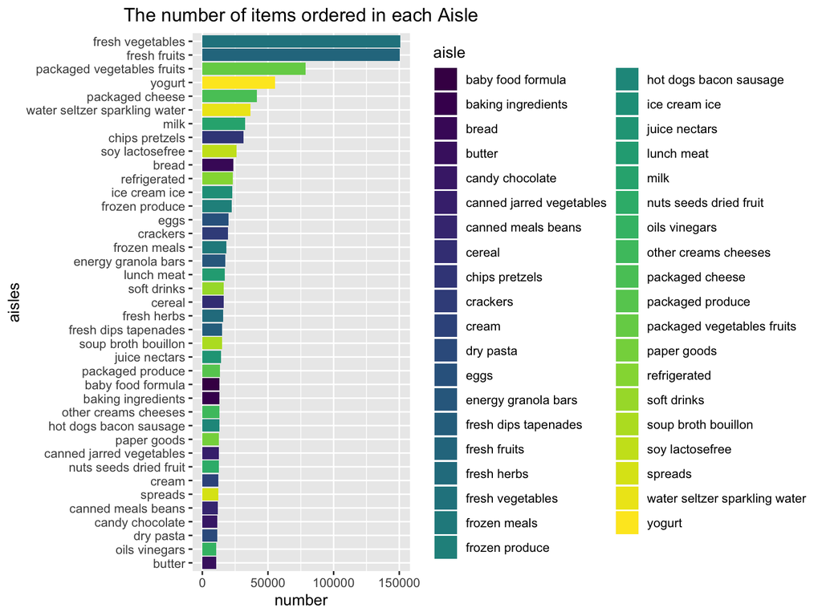

From the plot, we can clearly see the rank of number of items ordered in each aisle. The orders from fresh vegetables are the most and butter is the least.

## Table1: most populat items in each aisles

| group | product_name | order_times |
| --- | --- | --- |
| baking ingredients | Cane Sugar | 336 |
| baking ingredients | Light Brown Sugar | 499 |
| baking ingredients | Pure Baking Soda | 387 |
| dog food care | Organix Chicken & Brown Rice Recipe | 28 |
| dog food care | Small Dog Biscuits | 26 |
| dog food care | Snack Sticks Chicken & Rice Recipe Dog Treats | 30 |
| packaged vegetables fruits | Organic Baby Spinach | 9784 |
| packaged vegetables fruits | Organic Blueberries | 4966 |
| packaged vegetables fruits | Organic Raspberries | 5546 |

From the table, the most popular items from baking ingredients are cane sugar, light brown sugar and pure baking soda. In the group of dog food care, organix chicken&brown rice recipe, small dog biscuits, snack sticks chicken & rice recipe dog treats are the top3 popular items. And in the group of packaged vegetables fruits, organic baby spinach, organic blueberries, organic raspverries sells best.

## Table2: mean hour of a day ordered on each day

| product_name | Sun | Mon | Tue | Wed | Thur | Fri | Sat |
| --- | --- | --- | --- | --- | --- | --- | --- |
| Coffee Ice Cream | 13 | 14 | 15 | 15 | 15 | 12 | 13 |
| Pink Lady Apples | 13 | 11 | 11 | 14 | 11 | 12 | 11 |

From this table, we can clearly see the mean hour of the day at which pink lady apples and coffee ice cream are ordered on each day of the week. In order to see clearly, I round the value to integer.

# Problem2

In 2002, CT, FL, NC, MA, NJ, PA were observed at 7 or more locations.

In 2010, CO, PA, SC, OH, MA, NY, NE, WA, CA, MD, NC, TX, NJ, FL were observed at 7 or more locations.

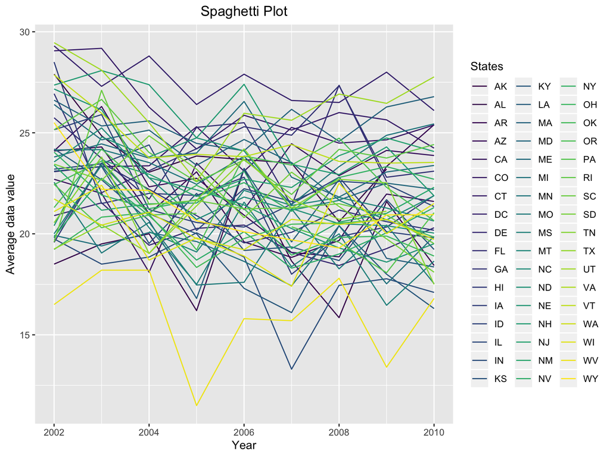

This figure has so many states information, so it’s not so clearly to see. We notice that most of the states fluctuate from 2002 to 2010.

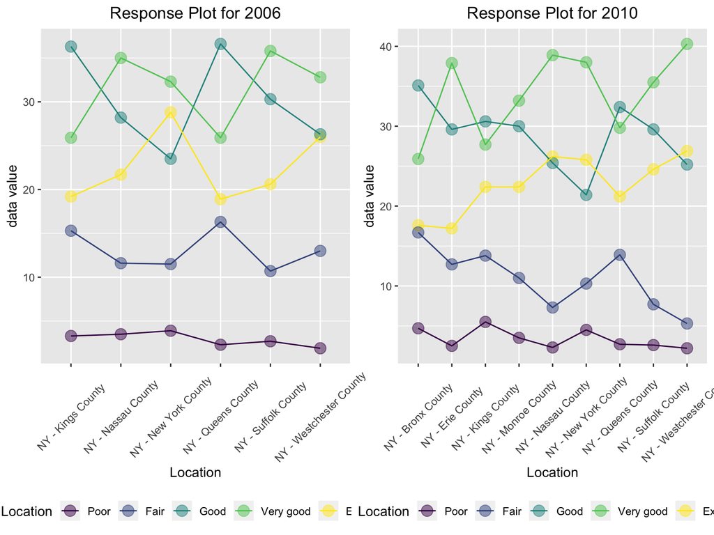

or In this way:

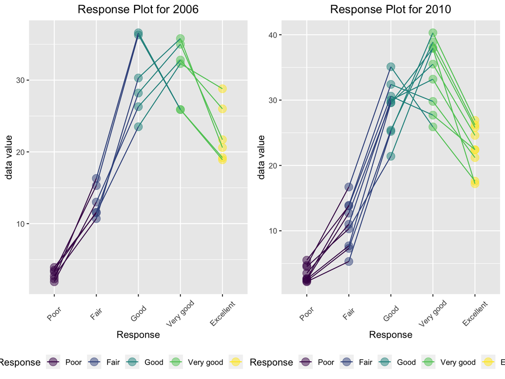

# Problem3

For this resulting dataset, there are 35 observations and 1444 variables. It also includes the week, day ID, weekend or weekday information.

| week | day_id | day | weekday_end | sum |
| --- | --- | --- | --- | --- |
| 1 | 1 | Friday | weekday | 480276 |
| 1 | 2 | Monday | weekday | 78525 |
| 1 | 3 | Saturday | weekend | 376017 |
| 1 | 4 | Sunday | weekend | 629710 |
| 1 | 5 | Thursday | weekday | 354987 |
| 1 | 6 | Tuesday | weekday | 306136 |
| 1 | 7 | Wednesday | weekday | 339209 |
| 2 | 8 | Friday | weekday | 568835 |
| 2 | 9 | Monday | weekday | 295427 |
| 2 | 10 | Saturday | weekend | 607024 |
| 2 | 11 | Sunday | weekend | 421781 |
| 2 | 12 | Thursday | weekday | 472059 |
| 2 | 13 | Tuesday | weekday | 423231 |
| 2 | 14 | Wednesday | weekday | 440948 |
| 3 | 15 | Friday | weekday | 467416 |
| 3 | 16 | Monday | weekday | 685906 |
| 3 | 17 | Saturday | weekend | 382914 |
| 3 | 18 | Sunday | weekend | 467027 |
| 3 | 19 | Thursday | weekday | 371226 |
| 3 | 20 | Tuesday | weekday | 381503 |
| 3 | 21 | Wednesday | weekday | 468772 |
| 4 | 22 | Friday | weekday | 154045 |
| 4 | 23 | Monday | weekday | 408898 |
| 4 | 24 | Saturday | weekend | 1436 |
| 4 | 25 | Sunday | weekend | 260613 |
| 4 | 26 | Thursday | weekday | 340287 |
| 4 | 27 | Tuesday | weekday | 319075 |
| 4 | 28 | Wednesday | weekday | 432626 |
| 5 | 29 | Friday | weekday | 620856 |
| 5 | 30 | Monday | weekday | 388950 |
| 5 | 31 | Saturday | weekend | 1436 |
| 5 | 32 | Sunday | weekend | 138417 |
| 5 | 33 | Thursday | weekday | 549654 |
| 5 | 34 | Tuesday | weekday | 367757 |
| 5 | 35 | Wednesday | weekday | 445257 |

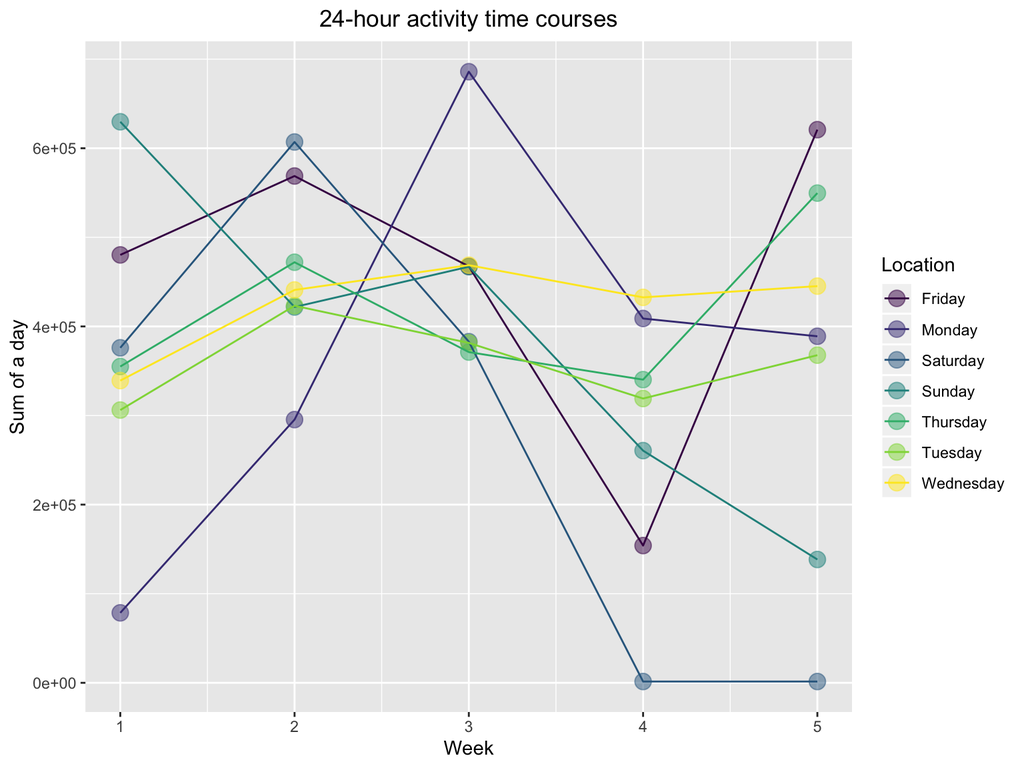